# Exercício 1 - LAB II

João Pedro Toledo

2023-02-28

Carregando pacotes

## Exercício 1 - Capítulo 1 - Decomposição

1. Produza um gráfico de série temporal (variável no eixo y e tempo no eixo x). Obtenha um gráfico das séries agregadas anualmente e um boxplot que sumarize os valores observados a fim de observar a sazonalidade. Comente os gráficos.
2. Decomponha as séries em seus componentes (tendência, efeito sazonal, e resíduos) e obtenha o gráfico das séries decompostas. Comente.

Para ter uma visão do trend (tendência) a sazonalidade pode ser removida agregando os dados em nível anual. Para isto utilizaremos a função *aggregate*. Cada sazonalidade pode ser visualizada utilizando um boxplot, com a função *cycle* para extrair a sazonalidade para cada item do banco de dados.

Carregando dados

```r
www <- "https://raw.githubusercontent.com/dallascard/Introductory_Time_Series_with_R_datasets/master/cbe.dat"
CBE <- read.table(www, header = T)

class(CBE)
```

```
## [1] "data.frame"
```

Transformando em time series

```r
cho.ts <- ts(CBE[, 1], start = 1958, freq = 12)
```

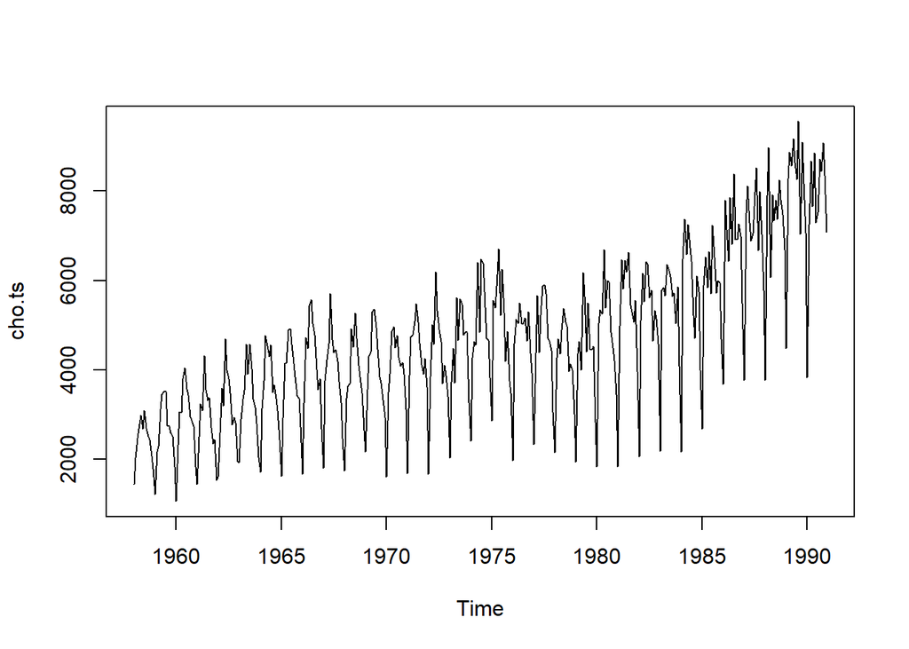

```r
plot(cho.ts)
```

Grafico de chocolate em toneladas na Australia de Janeiro 1958 até dezembro 1990 agregados

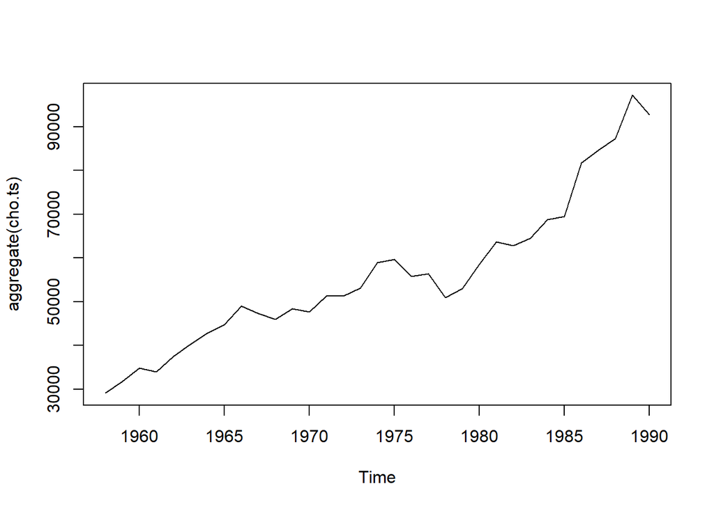

```r
plot(aggregate(cho.ts))
```

Ambos Gráficos mostram uma tendêndencia crescente ao longo do tempo. O primeiro evidencia a sazonalidade.

Gráfico BoxPlot por mês do ano

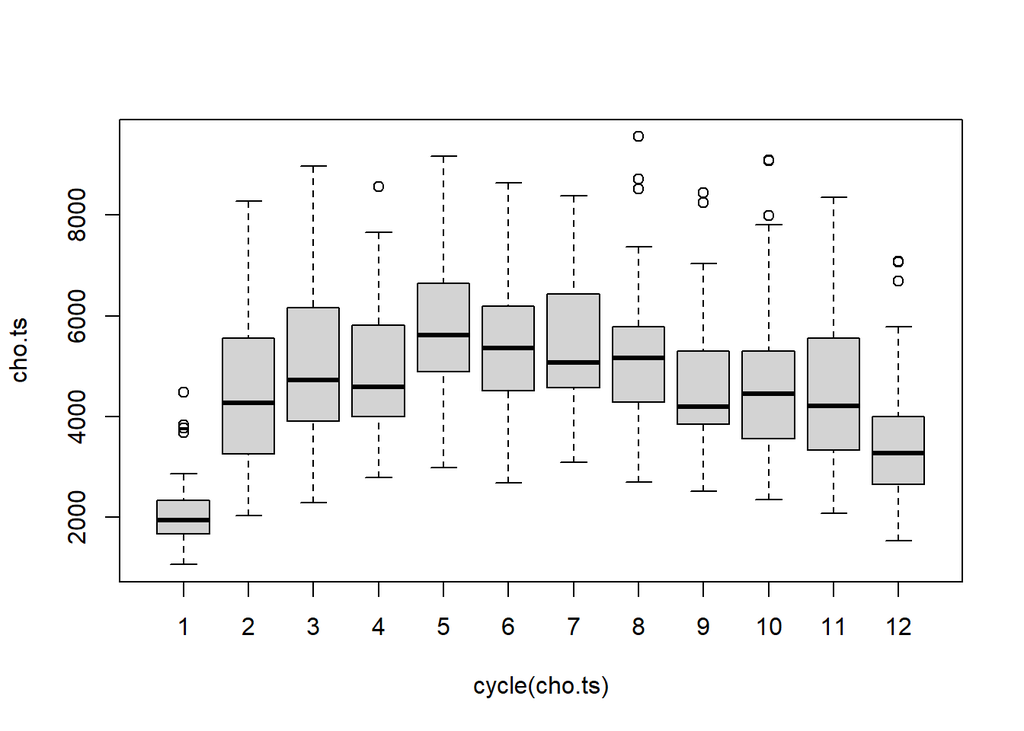

```r
boxplot(cho.ts ~ cycle(cho.ts))
```

Decomposição

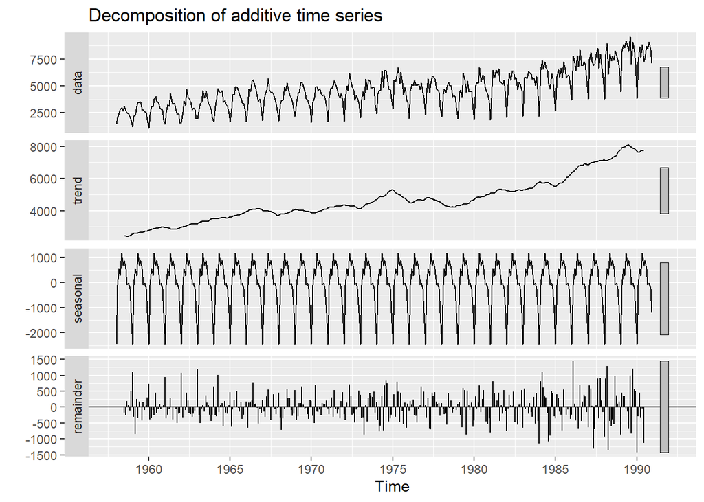

```r
autoplot(decompose(cho.ts))
```

Decompose estima tendência e efeito sazonal usando a decomposição com o método de médias moveis. Uma média móvel é uma média de um número especificado de valores de série temporal em torno de cada valor na série temporal, com exceção dos primeiros e últimos. Um problema quando se faz média móvel de séries com meses. Considerando a média de 12 meses consecutivos teriamos como t=1 (janeiro) e fazendo a média de Janeiro até Dezembro (12) teríamos uma média de t=6.5, contudo precisamos de um número integer. Assim fazemos a média de janeiro até dezembro e de fevereiro até janeiro utilizando a média de duas médias moveis correspondendo a t = 7. Este processo é chamado centring também sendo um exemplo de procedimento de smoothing.

De modo geral, a decomposição mostra uma tendência crescente ao longo do tempo, o efeito sazonal se mantém com característica de 2 grandes picos. Em relação aos residuos temos uma caracteristica esperada, sendo o que resta após o ajuste de um modelo. Para muitos modelos de séries temporais, os resíduos são iguais à diferença entre as observações e os valores ajustados correspondentes. Os resíduos são importantes para realizar analise sobre correlação.

## Extra

Metódos de smoothing - X11

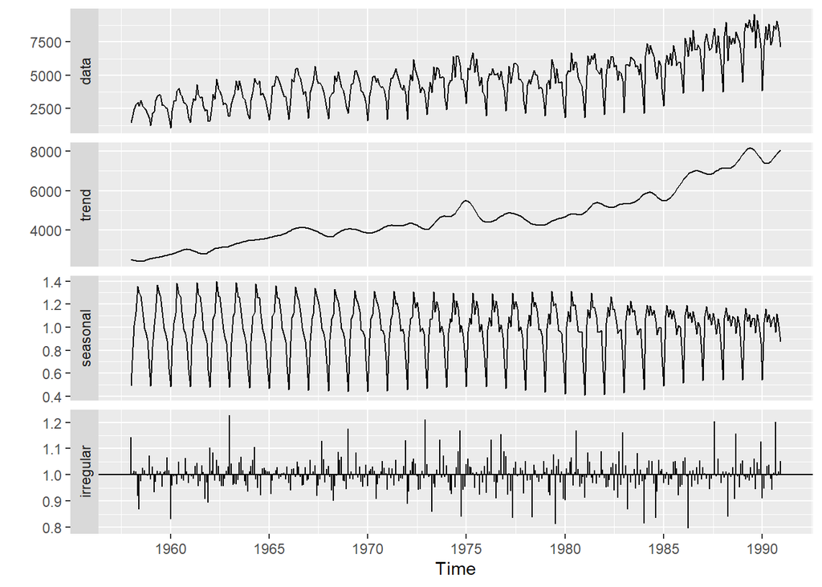

```r
autoplot(seas(cho.ts, x11=""))
```

Metodo X11 - Podemos observar que o x11 consegue modelar de forma mais eficiente o efeito seasonal do banco de dados, deixando-o de forma mais relaxada, isto quando comparado com o método das médias móveis utilizado acima. Outro ponto importante é a redução de correlação observada em irregular (remainder), no primeiro método temos vários pontos acima e abaixo de 0 mostrando maior correlação. Ainda temos outilers, mas ainda existe uma melhora.

Metódos de smoothing - SEATS

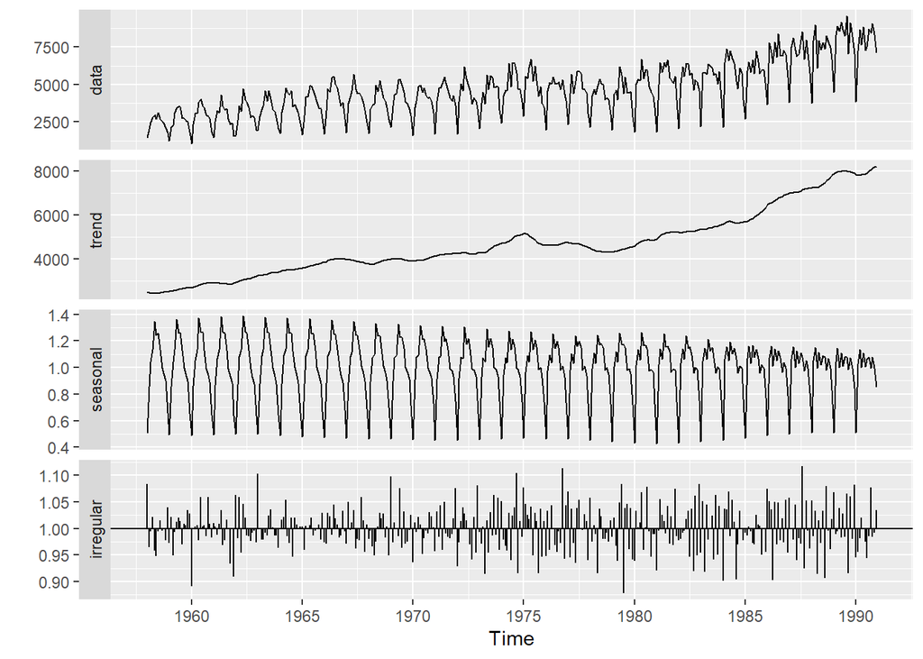

```r
autoplot(seas(cho.ts))
```

Metódos de smoothing - loess

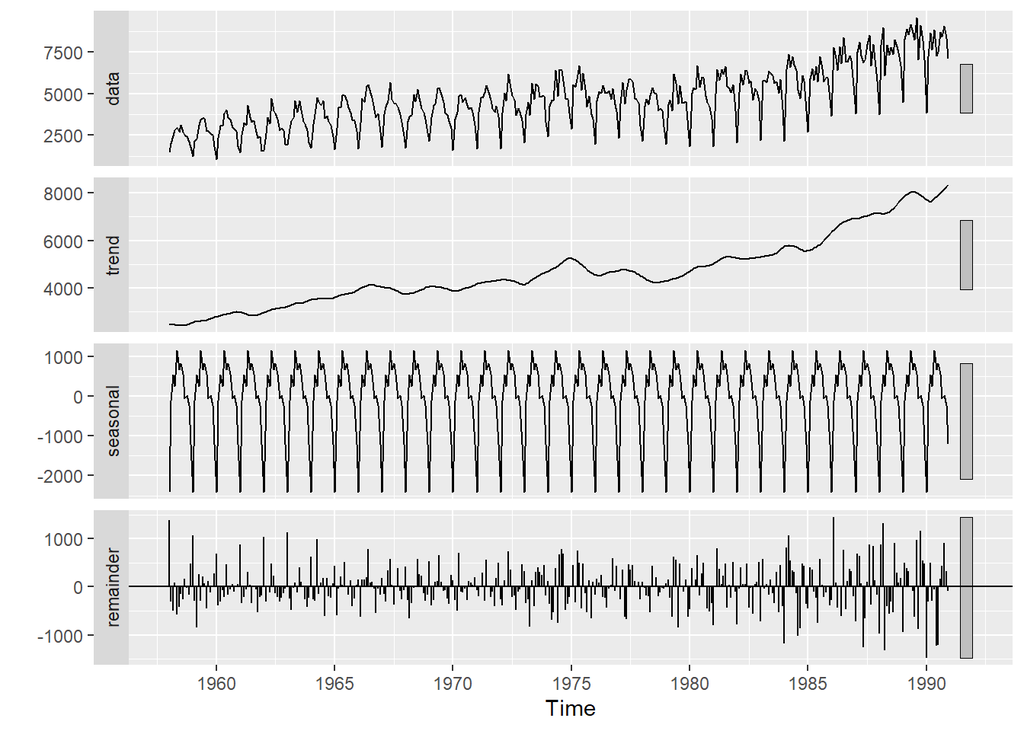

```r
autoplot(stl(cho.ts, s.window = 'periodic'))
```

A ponderação reduz a influência da outliers e é um exemplo de regressão robusta.

loess traz algo mais próximo dos métodos mais padrões, mantendo maior correlação e não ajustando de maneira mais eficiente a sazonalidade. Podemos tentar adicionar lag ou windown de correlação, contudo achar o intervalo manualmente é difícil e não provem um melhor ajuste ao modelo.

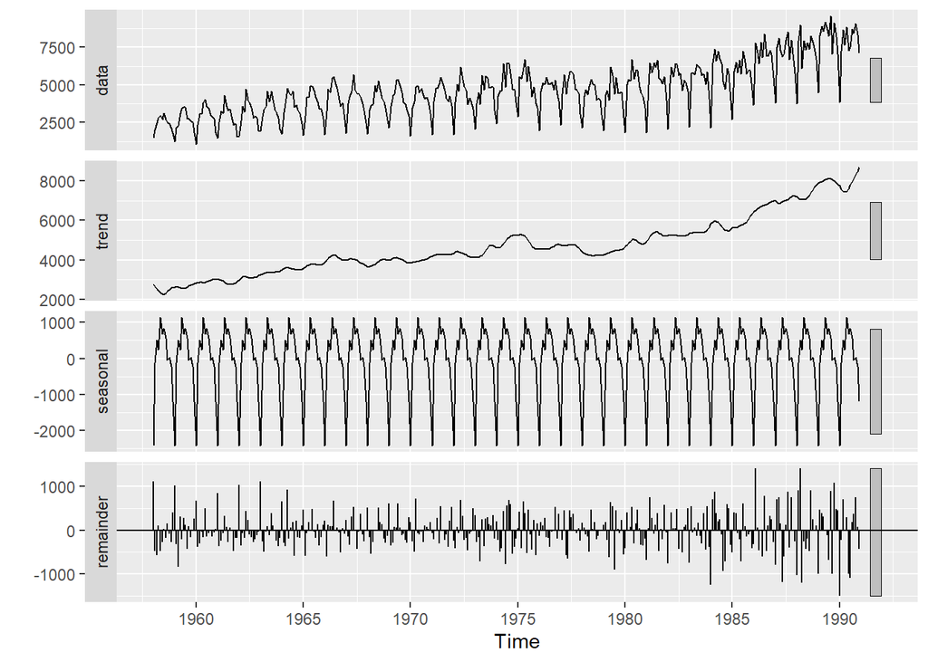

```r
autoplot(stl(cho.ts, s.window = 'periodic', t.window = 12))
```

[figure not shown]

```r
checkresiduals(remainder(seas(cho.ts, x11="")))
```

Checando residuos - X11

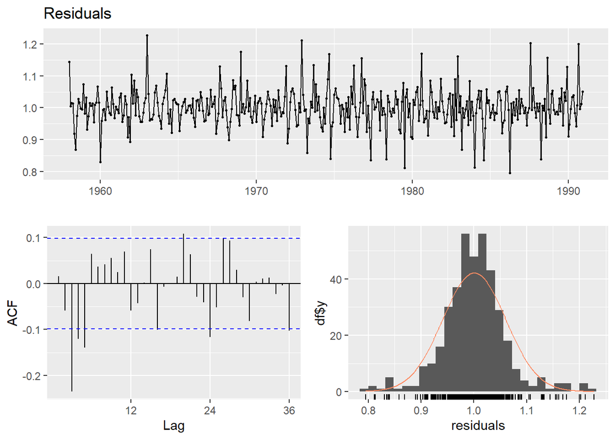

```r
checkresiduals(remainder(seas(cho.ts, x11="")))
```

Com o método X11 temos correlação com o gráfico de ACF x LAG, com algumas barras que escapam da linha azul, contudo ainda mostra uma melhora comparado com outros métodos.